# Project: Movie Data Analysis

- Introduction
- Data Wrangling
- Exploratory Data Analysis
- Conclusions

## Introduction

### Dataset Description

The Movie Database (TMDb) is a collection of a data set that contains information about 10,000 movies. However there are some insights to confirm about this dataset. Provided below are the records in the database. Due to some gliches, the table might not report all data, hence the data may have missing values.

Variable Description

- ID: Primary ID
- Imdb ID: Unique movie ID
- Popularity: Certainty of likeness
- Budget: Estimate of income for the movie
- Revenue: The returns on the movie
- Original Title: The name of the movie
- Cast: The actors of the movie
- Homepage: Website of the movie
- Director: The creator or maker of the movie
- Tagline: The movie's advertising slogan
- Keywords: Word attached to the movie title describing style or action taking place during the movie
- Overview: The movie sypnosis that summarizies the movie's storyline
- Runtime: The total timeframe of the movie
- Genres: The category of the movie
- Production Companies: The compnay producing the movie
- Release Date: The date the movie was released
- Vote Count: The total count of vote for the movie
- Vote Average: The total average vote for the movie
- Release Year: The year the movie was released
- Budget Adjusted: The adjusted estimate of income for the movie accounting for inflation
- Revenue Adjusted: The adjusted returns on the movie accounting for inflation

### Question(s) for Analysis

These are a few questions intended to be derived from the analysis:

1. Which movie had the highest vote count?
2. What are the top 10 movies in terms of Budget, Revenue and Profit?
3. Which movies are the most popular?
4. Which genres are the most popular?
5. What are the frequent production companies?
6. Which actors are the most popular?
7. Can we provide a list of directors that generate high revenues?

```python
# importing the libraries
import pandas as pd
import matplotlib.pyplot as plt
import numpy as np
import seaborn as sns
from datetime import datetime
%matplotlib inline
```

## Data Wrangling

```python
# Load the data and check the head
df = pd.read_csv('tmdb-movies.csv')
df.head()
```

|  | id | imdb_id | popularity | budget | revenue | original_title | cast | homepage | director | tagline | ... | overview | runtime | genres | production_companies | release_date | vote_count | vote_average | release_year | budget_adj | revenue_adj |
| --- | --- | --- | --- | --- | --- | --- | --- | --- | --- | --- | --- | --- | --- | --- | --- | --- | --- | --- | --- | --- | --- |
| 0 | 135397 | tt0369610 | 32.985763 | 150000000 | 1513528810 | Jurassic World | Chris Pratt\|Bryce Dallas Howard\|Irrfan Khan\|Vi... | http://www.jurassicworld.com/ | Colin Trevorrow | The park is open. | ... | Twenty-two years after the events of Jurassic ... | 124 | Action\|Adventure\|Science Fiction\|Thriller | Universal Studios\|Amblin Entertainment\|Legenda... | 6/9/15 | 5562 | 6.5 | 2015 | 1.379999e+08 | 1.392446e+09 |
| 1 | 76341 | tt1392190 | 28.419936 | 150000000 | 378436354 | Mad Max: Fury Road | Tom Hardy\|Charlize Theron\|Hugh Keays-Byrne\|Nic... | http://www.madmaxmovie.com/ | George Miller | What a Lovely Day. | ... | An apocalyptic story set in the furthest reach... | 120 | Action\|Adventure\|Science Fiction\|Thriller | Village Roadshow Pictures\|Kennedy Miller Produ... | 5/13/15 | 6185 | 7.1 | 2015 | 1.379999e+08 | 3.481613e+08 |
| 2 | 262500 | tt2908446 | 13.112507 | 110000000 | 295238201 | Insurgent | Shailene Woodley\|Theo James\|Kate Winslet\|Ansel... | http://www.thedivergentseries.movie/#insurgent | Robert Schwentke | One Choice Can Destroy You | ... | Beatrice Prior must confront her inner demons ... | 119 | Adventure\|Science Fiction\|Thriller | Summit Entertainment\|Mandeville Films\|Red Wago... | 3/18/15 | 2480 | 6.3 | 2015 | 1.012000e+08 | 2.716190e+08 |
| 3 | 140607 | tt2488496 | 11.173104 | 200000000 | 2068178225 | Star Wars: The Force Awakens | Harrison Ford\|Mark Hamill\|Carrie Fisher\|Adam D... | http://www.starwars.com/films/star-wars-episod... | J.J. Abrams | Every generation has a story. | ... | Thirty years after defeating the Galactic Empi... | 136 | Action\|Adventure\|Science Fiction\|Fantasy | Lucasfilm\|Truenorth Productions\|Bad Robot | 12/15/15 | 5292 | 7.5 | 2015 | 1.839999e+08 | 1.902723e+09 |
| 4 | 168259 | tt2820852 | 9.335014 | 190000000 | 1506249360 | Furious 7 | Vin Diesel\|Paul Walker\|Jason Statham\|Michelle ... | http://www.furious7.com/ | James Wan | Vengeance Hits Home | ... | Deckard Shaw seeks revenge against Dominic Tor... | 137 | Action\|Crime\|Thriller | Universal Pictures\|Original Film\|Media Rights ... | 4/1/15 | 2947 | 7.3 | 2015 | 1.747999e+08 | 1.385749e+09 |

5 rows × 21 columns

```python
#shape of the data (rows, columns)
df.shape
```

```
(10866, 21)
```

```python
# check the info
df.info()
```

```
<class 'pandas.core.frame.DataFrame'>
RangeIndex: 10866 entries, 0 to 10865
Data columns (total 21 columns):
 #   Column                Non-Null Count  Dtype
---  ------                --------------  -----
 0   id                    10866 non-null  int64
 1   imdb_id               10856 non-null  object
 2   popularity            10866 non-null  float64
 3   budget                10866 non-null  int64
 4   revenue               10866 non-null  int64
 5   original_title        10866 non-null  object
 6   cast                  10790 non-null  object
 7   homepage              2936 non-null   object
 8   director              10822 non-null  object
 9   tagline               8042 non-null   object
 10  keywords              9373 non-null   object
 11  overview              10862 non-null  object
 12  runtime               10866 non-null  int64
 13  genres                10843 non-null  object
 14  production_companies  9836 non-null   object
 15  release_date          10866 non-null  object
 16  vote_count            10866 non-null  int64
 17  vote_average          10866 non-null  float64
 18  release_year          10866 non-null  int64
 19  budget_adj            10866 non-null  float64
 20  revenue_adj           10866 non-null  float64
dtypes: float64(4), int64(6), object(11)
memory usage: 1.7+ MB
```

```python
#description of the numeric columns in dataset
df.describe()
```

|  | id | popularity | budget | revenue | runtime | vote_count | vote_average | release_year | budget_adj | revenue_adj |
| --- | --- | --- | --- | --- | --- | --- | --- | --- | --- | --- |
| count | 10866.000000 | 10866.000000 | 1.086600e+04 | 1.086600e+04 | 10866.000000 | 10866.000000 | 10866.000000 | 10866.000000 | 1.086600e+04 | 1.086600e+04 |
| mean | 66064.177434 | 0.646441 | 1.462570e+07 | 3.982332e+07 | 102.070863 | 217.389748 | 5.974922 | 2001.322658 | 1.755104e+07 | 5.136436e+07 |
| std | 92130.136561 | 1.000185 | 3.091321e+07 | 1.170035e+08 | 31.381405 | 575.619058 | 0.935142 | 12.812941 | 3.430616e+07 | 1.446325e+08 |
| min | 5.000000 | 0.000065 | 0.000000e+00 | 0.000000e+00 | 0.000000 | 10.000000 | 1.500000 | 1960.000000 | 0.000000e+00 | 0.000000e+00 |
| 25% | 10596.250000 | 0.207583 | 0.000000e+00 | 0.000000e+00 | 90.000000 | 17.000000 | 5.400000 | 1995.000000 | 0.000000e+00 | 0.000000e+00 |
| 50% | 20669.000000 | 0.383856 | 0.000000e+00 | 0.000000e+00 | 99.000000 | 38.000000 | 6.000000 | 2006.000000 | 0.000000e+00 | 0.000000e+00 |
| 75% | 75610.000000 | 0.713817 | 1.500000e+07 | 2.400000e+07 | 111.000000 | 145.750000 | 6.600000 | 2011.000000 | 2.085325e+07 | 3.369710e+07 |
| max | 417859.000000 | 32.985763 | 4.250000e+08 | 2.781506e+09 | 900.000000 | 9767.000000 | 9.200000 | 2015.000000 | 4.250000e+08 | 2.827124e+09 |

```python
# Check for null and missing values in %
m = df.isna().sum()*100/len(df)
m
```

```
id                       0.000000
imdb_id                  0.092030
popularity               0.000000
budget                   0.000000
revenue                  0.000000
original_title           0.000000
cast                     0.699429
homepage                72.979937
director                 0.404933
tagline                 25.989324
keywords                13.740107
overview                 0.036812
runtime                  0.000000
genres                   0.211669
production_companies     9.479109
release_date             0.000000
vote_count               0.000000
vote_average             0.000000
release_year             0.000000
budget_adj               0.000000
revenue_adj              0.000000
dtype: float64
```

### Data Cleaning

We will drop the columns that won’t be used for our analysis, fill the missing value in the columns, check any duplicated rows.

```python
# drop columns that don't have significant importance to the dataset
df.drop(['id','homepage','tagline','keywords','overview'], axis=1, inplace=True)
```

```python
# Fill the categorical columns with missing values with the mode
cols = ["genres", "production_companies", "imdb_id", "cast","director"]
df[cols]=df[cols].fillna(df.mode().iloc[0])
```

```python
# No duplicated row
df.duplicated().sum()
```

```
1
```

```python
# Check if pandas columns contains all zeros
filter = (df == 0).any()
sub_df = df.loc[:, filter]
print(sub_df)
```

```
          budget     revenue  runtime    budget_adj   revenue_adj
0      150000000  1513528810      124  1.379999e+08  1.392446e+09
1      150000000   378436354      120  1.379999e+08  3.481613e+08
2      110000000   295238201      119  1.012000e+08  2.716190e+08
3      200000000  2068178225      136  1.839999e+08  1.902723e+09
4      190000000  1506249360      137  1.747999e+08  1.385749e+09
...          ...         ...      ...           ...           ...
10861          0           0       95  0.000000e+00  0.000000e+00
10862          0           0      176  0.000000e+00  0.000000e+00
10863          0           0       94  0.000000e+00  0.000000e+00
10864          0           0       80  0.000000e+00  0.000000e+00
10865      19000           0       74  1.276423e+05  0.000000e+00

[10866 rows x 5 columns]
```

```python
# count the columns have value less than 0
a= (df['budget'] <= 0).sum()
b= (df['revenue'] <= 0).sum()
c= (df['runtime'] <= 0).sum()
a,b,c
```

```
(5696, 6016, 31)
```

```python
# Replace zero values with mean
cols = ['budget','revenue','runtime','budget_adj','revenue_adj']
for col in df.columns:
    val = df[cols].mean()
    df[cols] = df[cols].replace(0, val)
```

```python
# confirm datatypes
df.dtypes
```

```
imdb_id                  object
popularity              float64
budget                  float64
revenue                 float64
original_title           object
cast                     object
director                 object
runtime                 float64
genres                   object
production_companies     object
release_date             object
vote_count                int64
vote_average            float64
release_year              int64
budget_adj              float64
revenue_adj             float64
dtype: object
```

```python
# change datatypes of release date and runtime
df['release_date'] = pd.to_datetime(df['release_date'])
df[['budget','revenue','runtime']]=df[['budget','revenue','runtime']].astype(int)
```

```python
# recheck new dataframe and info
df.head(1)
```

|  | imdb_id | popularity | budget | revenue | original_title | cast | director | runtime | genres | production_companies | release_date | vote_count | vote_average | release_year | budget_adj | revenue_adj |
| --- | --- | --- | --- | --- | --- | --- | --- | --- | --- | --- | --- | --- | --- | --- | --- | --- |
| 0 | tt0369610 | 32.985763 | 150000000 | 1513528810 | Jurassic World | Chris Pratt\|Bryce Dallas Howard\|Irrfan Khan\|Vi... | Colin Trevorrow | 124 | Action\|Adventure\|Science Fiction\|Thriller | Universal Studios\|Amblin Entertainment\|Legenda... | 2015-06-09 | 5562 | 6.5 | 2015 | 1.379999e+08 | 1.392446e+09 |

```python
df.info()
```

```
<class 'pandas.core.frame.DataFrame'>
RangeIndex: 10866 entries, 0 to 10865
Data columns (total 16 columns):
 #   Column                Non-Null Count  Dtype
---  ------                --------------  -----
 0   imdb_id               10866 non-null  object
 1   popularity            10866 non-null  float64
 2   budget                10866 non-null  int64
 3   revenue               10866 non-null  int64
 4   original_title        10866 non-null  object
 5   cast                  10866 non-null  object
 6   director              10866 non-null  object
 7   runtime               10866 non-null  int64
 8   genres                10866 non-null  object
 9   production_companies  10866 non-null  object
 10  release_date          10866 non-null  datetime64[ns]
 11  vote_count            10866 non-null  int64
 12  vote_average          10866 non-null  float64
 13  release_year          10866 non-null  int64
 14  budget_adj            10866 non-null  float64
 15  revenue_adj           10866 non-null  float64
dtypes: datetime64[ns](1), float64(4), int64(5), object(6)
memory usage: 1.3+ MB
```

```python
df.describe()
```

|  | popularity | budget | revenue | runtime | vote_count | vote_average | release_year | budget_adj | revenue_adj |
| --- | --- | --- | --- | --- | --- | --- | --- | --- | --- |
| count | 10866.000000 | 1.086600e+04 | 1.086600e+04 | 10866.000000 | 10866.000000 | 10866.000000 | 10866.000000 | 1.086600e+04 | 1.086600e+04 |
| mean | 0.646441 | 2.229255e+07 | 6.187164e+07 | 102.361863 | 217.389748 | 5.974922 | 2001.322658 | 2.675136e+07 | 7.980243e+07 |
| std | 1.000185 | 2.801245e+07 | 1.110204e+08 | 30.902783 | 575.619058 | 0.935142 | 12.812941 | 3.050850e+07 | 1.365610e+08 |
| min | 0.000065 | 1.000000e+00 | 2.000000e+00 | 2.000000 | 10.000000 | 1.500000 | 1960.000000 | 9.210911e-01 | 2.370705e+00 |
| 25% | 0.207583 | 1.462570e+07 | 3.982332e+07 | 90.000000 | 17.000000 | 5.400000 | 1995.000000 | 1.755104e+07 | 5.136436e+07 |
| 50% | 0.383856 | 1.462570e+07 | 3.982332e+07 | 99.000000 | 38.000000 | 6.000000 | 2006.000000 | 1.755104e+07 | 5.136436e+07 |
| 75% | 0.713817 | 1.500000e+07 | 3.982332e+07 | 111.000000 | 145.750000 | 6.600000 | 2011.000000 | 2.085325e+07 | 5.136436e+07 |
| max | 32.985763 | 4.250000e+08 | 2.781506e+09 | 900.000000 | 9767.000000 | 9.200000 | 2015.000000 | 4.250000e+08 | 2.827124e+09 |

# Feature Engineering

```python
# Create Profit column
df['profit'] = df['revenue'] - df['budget']
```

```python
df.head(1)
```

|  | imdb_id | popularity | budget | revenue | original_title | cast | director | runtime | genres | production_companies | release_date | vote_count | vote_average | release_year | budget_adj | revenue_adj | profit |
| --- | --- | --- | --- | --- | --- | --- | --- | --- | --- | --- | --- | --- | --- | --- | --- | --- | --- |
| 0 | tt0369610 | 32.985763 | 150000000 | 1513528810 | Jurassic World | Chris Pratt\|Bryce Dallas Howard\|Irrfan Khan\|Vi... | Colin Trevorrow | 124 | Action\|Adventure\|Science Fiction\|Thriller | Universal Studios\|Amblin Entertainment\|Legenda... | 2015-06-09 | 5562 | 6.5 | 2015 | 1.379999e+08 | 1.392446e+09 | 1363528810 |

## Exploratory Data Analysis

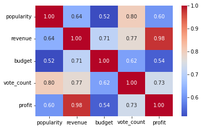

```python
# Correlation matrix between numerical values Popularity,Revenue,Budget,Vote_count and Profit
num_corr = sns.heatmap(df[["popularity","revenue","budget","vote_count","profit"]].corr(),annot=True, fmt = ".2f", cmap = "coolwarm")
```

We can also find that revenue has a significant correlation with the budget probability.

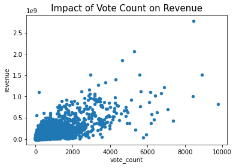

```python
# Is there any impact of Vote Count on Revenue
df.plot(x='vote_count', y='revenue',kind='scatter')
plt.title('Impact of Vote Count on Revenue',fontsize=15)
```

Based on this scatterplot of Revenue against Vote Count we can see that there is a significative impact.

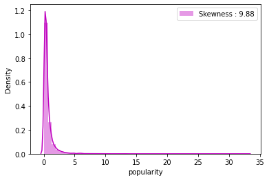

```python
# Explore Popularity distribution
pop = sns.distplot(df["popularity"], color="m", label="Skewness : %.2f"%(df["popularity"].skew()))
pop = pop.legend(loc="best")
```

As we can see, Population distribution is very skewed. This can lead to overweigth very high values in the analysis.

In this case, it is better to transform it with the log function to reduce this skew.

```python
# Apply log to Fare to reduce skewness distribution
df["popularity"] = df["popularity"].map(lambda i: np.log(i) if i > 0 else 0)
```

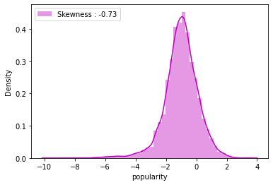

```python
pop = sns.distplot(df["popularity"], color="m", label="Skewness : %.2f"%(df["popularity"].skew()))
pop = pop.legend(loc="best")
```

From this we can see that a moderately skewed distribution as been achieved.

## Which movie had the highest vote count?

```python
df[['original_title','vote_count']].sort_values(by='vote_count', ascending=False).head(10)
```

|  | original_title | vote_count |
| --- | --- | --- |
| 1919 | Inception | 9767 |
| 4361 | The Avengers | 8903 |
| 1386 | Avatar | 8458 |
| 2875 | The Dark Knight | 8432 |
| 4364 | Django Unchained | 7375 |
| 4382 | The Hunger Games | 7080 |
| 5425 | Iron Man 3 | 6882 |
| 4363 | The Dark Knight Rises | 6723 |
| 629 | Interstellar | 6498 |
| 4367 | The Hobbit: An Unexpected Journey | 6417 |

Or for a more visual representation we could plot a bar chart with the vote count:

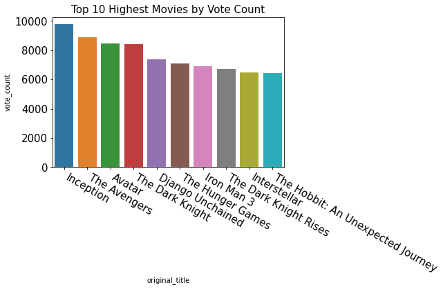

```python
top_10 = df[['original_title','vote_count']].sort_values(by='vote_count', ascending=False).set_index('original_title').head(10)
sns.barplot(data=top_10, x=top_10.index, y='vote_count');
plt.xticks(ha='left', rotation=-30, fontsize=15);
plt.yticks(fontsize=15)
plt.title('Top 10 Highest Movies by Vote Count', fontsize=15);
```

As we can see, the Movie "Inception" had the highest vote count.

## What are the top 10 movies in terms of Budget, Revenue and Profit?

```python
cols = ['budget', 'revenue', 'profit']
for c in cols:
    display(df[[f'{c}', 'original_title']].sort_values(f'{c}', ascending=False).head(10))
```

|  | budget | original_title |
| --- | --- | --- |
| 2244 | 425000000 | The Warrior's Way |
| 3375 | 380000000 | Pirates of the Caribbean: On Stranger Tides |
| 7387 | 300000000 | Pirates of the Caribbean: At World's End |
| 14 | 280000000 | Avengers: Age of Ultron |
| 6570 | 270000000 | Superman Returns |
| 4411 | 260000000 | John Carter |
| 1929 | 260000000 | Tangled |
| 7394 | 258000000 | Spider-Man 3 |
| 5508 | 255000000 | The Lone Ranger |
| 4367 | 250000000 | The Hobbit: An Unexpected Journey |

|  | revenue | original_title |
| --- | --- | --- |
| 1386 | 2781505847 | Avatar |
| 3 | 2068178225 | Star Wars: The Force Awakens |
| 5231 | 1845034188 | Titanic |
| 4361 | 1519557910 | The Avengers |
| 0 | 1513528810 | Jurassic World |
| 4 | 1506249360 | Furious 7 |
| 14 | 1405035767 | Avengers: Age of Ultron |
| 3374 | 1327817822 | Harry Potter and the Deathly Hallows: Part 2 |
| 5422 | 1274219009 | Frozen |
| 5425 | 1215439994 | Iron Man 3 |

|  | profit | original_title |
| --- | --- | --- |
| 1386 | 2544505847 | Avatar |
| 3 | 1868178225 | Star Wars: The Force Awakens |
| 5231 | 1645034188 | Titanic |
| 0 | 1363528810 | Jurassic World |
| 4 | 1316249360 | Furious 7 |
| 4361 | 1299557910 | The Avengers |
| 3374 | 1202817822 | Harry Potter and the Deathly Hallows: Part 2 |
| 14 | 1125035767 | Avengers: Age of Ultron |
| 5422 | 1124219009 | Frozen |
| 8094 | 1084279658 | The Net |

We can infer from this that in terms of Budget, "The Warrior's Way" movie was the highest while movie "Avatar" generated the highest Profit and Revenue.

## Which movies are the most popular?

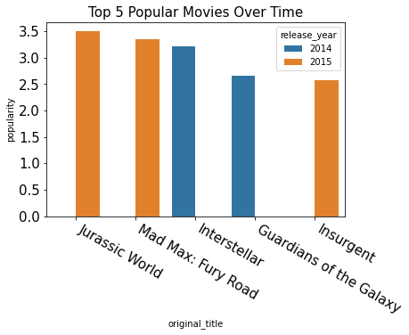

```python
top_5 = df[['original_title','popularity', 'release_year']].sort_values(by='popularity', ascending=False).set_index('original_title').head(5)
sns.barplot(data=top_5, x=top_5.index, y='popularity', hue='release_year');
plt.xticks(ha='left', rotation=-30, fontsize=15);
plt.yticks(fontsize=15)
plt.title('Top 5 Popular Movies Over Time', fontsize=15);
```

As we can see in 2015, the movie "Jurassic World" was the most popular while in 2014 the movie "Intersellar" was the most popular.

```python
# checking the year that released the most movies
df[['original_title']].groupby(df['release_year']).count().sort_values(['original_title'], ascending=False).head(20)
```

| release_year | original_title |
| --- | --- |
| 2014 | 700 |
| 2013 | 659 |
| 2015 | 629 |
| 2012 | 588 |
| 2011 | 540 |
| 2009 | 533 |
| 2008 | 496 |
| 2010 | 490 |
| 2007 | 438 |
| 2006 | 408 |
| 2005 | 364 |
| 2004 | 307 |
| 2003 | 281 |
| 2002 | 266 |
| 2001 | 242 |
| 2000 | 227 |
| 1999 | 224 |
| 1998 | 210 |
| 1996 | 204 |
| 1997 | 192 |

The year that released the most movies is 2014

## Which are the most popular genres?

The most popular genres are:

```python
genre_popularity = (df.genres.str.split('|')
                      .explode()
                      .value_counts()
                      .sort_values(ascending=False))
genre_popularity.head(10)
```

```
Drama              4761
Comedy             3816
Thriller           2908
Action             2385
Romance            1712
Horror             1637
Adventure          1471
Crime              1355
Family             1231
Science Fiction    1230
Name: genres, dtype: int64
```

Or for a more visual representation we could plot a word-cloud with the genres:

```
(-0.5, 999.5, 399.5, -0.5)
```

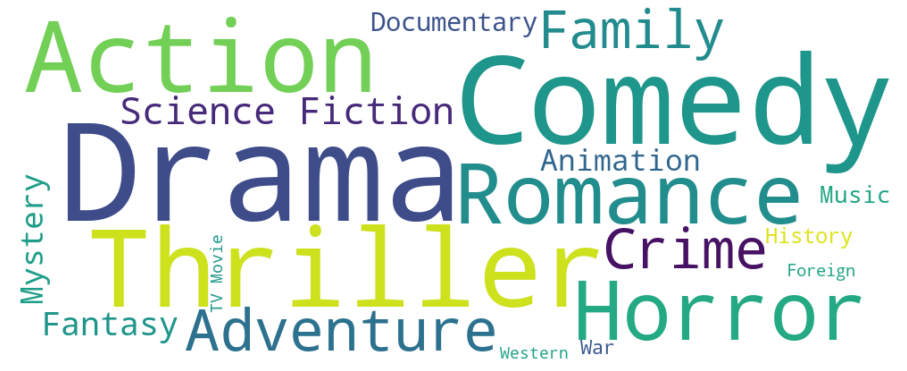

```python
from wordcloud import WordCloud
genre_wc = WordCloud(width=1000,height=400, background_color='white')
genre_wc.generate_from_frequencies(genre_popularity.to_dict())

plt.figure(figsize=(16, 8))
plt.imshow(genre_wc, interpolation="bilinear")
plt.axis('off')
```

```python
# checking data on movie based on History
df.query('genres == "History"')
```

|  | imdb_id | popularity | budget | revenue | original_title | cast | director | runtime | genres | production_companies | release_date | vote_count | vote_average | release_year | budget_adj | revenue_adj | profit |
| --- | --- | --- | --- | --- | --- | --- | --- | --- | --- | --- | --- | --- | --- | --- | --- | --- | --- |
| 9002 | tt0138097 | 0.057546 | 25000000 | 289317794 | Shakespeare in Love | Joseph Fiennes\|Gwyneth Paltrow\|Geoffrey Rush\|T... | John Madden | 122 | History | Miramax Films\|Universal Pictures\|Bedford Falls... | 1998-12-11 | 399 | 6.7 | 1998 | 3.344239e+07 | 3.870191e+08 | 264317794 |

## What are the frequent production companies?

```python
prod_popularity = (df.production_companies.str.split('|')
                      .explode()
                      .value_counts()
                      .sort_values(ascending=False))
prod_popularity.head(10)
```

```
Paramount Pictures                        1461
Universal Pictures                         522
Warner Bros.                               509
Twentieth Century Fox Film Corporation     282
Columbia Pictures                          272
New Line Cinema                            219
Metro-Goldwyn-Mayer (MGM)                  218
Walt Disney Pictures                       214
Touchstone Pictures                        178
Columbia Pictures Corporation              160
Name: production_companies, dtype: int64
```

We can infer from this that the most frequent production companies are Paramount Pictures, Universal Pictures and Warner Bros.

## Which actors are the most popular?

The most popular actors are:

```python
cast_popularity = (df.cast.str.split('|')
                      .explode()
                      .value_counts()
                      .sort_values(ascending=False))
cast_popularity.head(10)
```

```
Louis C.K.           86
Robert De Niro       72
Samuel L. Jackson    71
Bruce Willis         62
Nicolas Cage         61
Michael Caine        53
Robin Williams       51
John Cusack          50
John Goodman         49
Morgan Freeman       49
Name: cast, dtype: int64
```

As we can see the popular actors are Louis C.K., Robert De Niro and Samuel L. Jackson amongst others.

## Can we provide a list of directors that generate high revenues?

```python
top_10 = df[['director','revenue']].sort_values(by='revenue', ascending=False)
top_10.head(10)
```

|  | director | revenue |
| --- | --- | --- |
| 1386 | James Cameron | 2781505847 |
| 3 | J.J. Abrams | 2068178225 |
| 5231 | James Cameron | 1845034188 |
| 4361 | Joss Whedon | 1519557910 |
| 0 | Colin Trevorrow | 1513528810 |
| 4 | James Wan | 1506249360 |
| 14 | Joss Whedon | 1405035767 |
| 3374 | David Yates | 1327817822 |
| 5422 | Chris Buck\|Jennifer Lee | 1274219009 |
| 5425 | Shane Black | 1215439994 |

As we can see James Cameron who ranked in the first and third position generated the highest revenue.

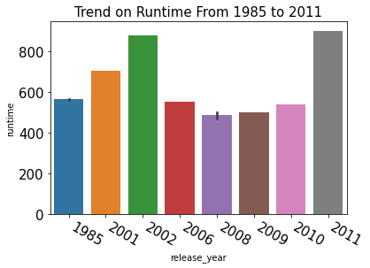

```python
# How does runtime trend overtime
top_10 = df[['runtime','release_year']].sort_values(by='runtime', ascending=False).set_index('release_year').head(10)
sns.barplot(data=top_10, x=top_10.index, y='runtime');
plt.xticks(ha='left', rotation=-30, fontsize=15);
plt.yticks(fontsize=15)
plt.title('Trend on Runtime From 1985 to 2011', fontsize=15);
```